# Into to Data Science - Capstone Project (Data Story)

John Campi

Jan. 09, 2019

# 1 Project Overview

## 1.1 What is the problem this project addresses?

Identify the key instrument sensors of a semiconductor manufacturing line and model the alarm conditions for potential chip failures.

## 1.2 Who is your client and why do they care about this problem? In other words, what will your client DO or DECIDE based on your analysis that they wouldn’t have otherwise?

This capability would be sought out by any semiconductor manufacturer who wants to maximize their yield. Currently wafers are tested after specific process levels are completed. Much of the critical testing can’t be performed until very far along in the manufacturing process. Thus a failure early in the process will consume costly resources as the wafer continues onto other fabrication steps, only to be scrapped at the end. If statistical sampling is used then there’s also the added risk of failing chips shipping to customers. Having the ability to catch failures in almost real time during any process step minimizes the chance of failure propagation and improves isolation time of equipment issues thereby greatly improving yield and reducing costs.

## 1.3 What data are you going to use for this? How will you acquire this data?

The date used for ths project will be the [**SECOM Data Set**](http://archive.ics.uci.edu/ml/datasets/secom) which is publicly available from UCI archive. The dataset is comprised of 1567 observations, one observation per wafer fabricated, 591 variables corresponding to various sensors in fabrication equipment, with 104 failing observations total.

## 1.4 In brief, outline your approach to solving this problem.

- The first step is to identify any irrelevant variables to try and reduce the total number of variables in the analysis.
- Next address missing data.
> - Any variable missing more than 10% of the total observations cannot accurately contribute to a model so will be dropped from the analysis.
> - Remaining missing data will be imputed.
- Due to the asymmetry in the number of observed fails to the total number of observation, a class rebalancing technique such as Synthetic Minority Over-sampling Technique (SMOTE) will need to be applied.
- Next split data into a training, tuning and verification set.
- Finally, perform logistic regression on the training data to identify the key model variable, apply machine learning techniques and tune the model then verify final model accuracy and sensitivity.

## 1.5 What are your deliverables? Typically, this would include code, along with a paper and/or a slide deck.

- The primary deliverable for this project is a categorical model, which given data from a similar fab and in the same format, could be used to predict pass/fail classes of finished wafers.
- A report describing the methodology and model. The R program can be included as an appendix.
- A slide show presenting the overall procedure and benefits.

# 2 Data Wrangling

## 2.1 Data Wrangling - Summary of Approach.

- Assemble csv files and update variable names and format as needed.
- Remove irrelevant variables.
- Classify all missing data as “NA”.
- Impute missing data.

## 2.2 Assemble Initial Dataset.

The [SECOM Data Set](http://archive.ics.uci.edu/ml/datasets/secom) consists of two csv files. The first is a list of pass/fail and date/time results, one entry per lot run, and the other contains the corresponding numeric results of sensor readings from a semiconductor manufacturing line. The data files do not contain a header so variable names ‘Status’, ‘Date’, and ‘Time’ were assigned for pass = -1 / fail = +1, date and time. The ‘Status’ variable is then updated to pass = 0 / fail = +1 for convenience when fitting the data to categorical models. The remaining variables assumed default names: V1, V2, etc. Table 2.1 below shows a sampling of the initial dataset. Since the sensor variables are not named in the original dataset, and since no information is provided about the physical meaning, source or process order of each sensor’s data, there is no way to attribute any process or business meaning to the data. Therefore the analysis herein will take a “black box” approach.

Table 2.1: Sampling of the SECOM dataset.

| Status | Date | Time | V1 | V2 | V3 | V4 |
| --- | --- | --- | --- | --- | --- | --- |
| 0 | 19/07/2008 | 11:55:00 | 3030.93 | 2564.00 | 2187.733 | 1411.1265 |
| 0 | 19/07/2008 | 12:32:00 | 3095.78 | 2465.14 | 2230.422 | 1463.6606 |
| 1 | 19/07/2008 | 13:17:00 | 2932.61 | 2559.94 | 2186.411 | 1698.0172 |
| 0 | 19/07/2008 | 14:43:00 | 2988.72 | 2479.90 | 2199.033 | 909.7926 |
| 0 | 19/07/2008 | 15:22:00 | 3032.24 | 2502.87 | 2233.367 | 1326.5200 |

## 2.3 Initial Cleanup

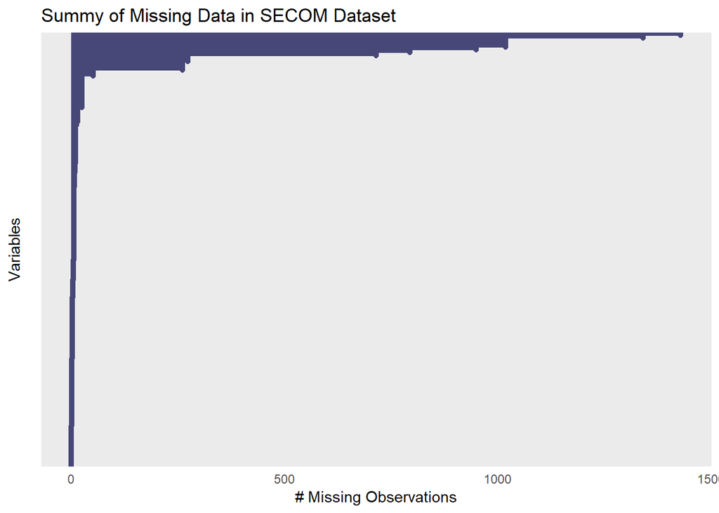

Fig. 2.1: Visualization of initial missingness.

## 2.4 Imputation

There are several R packages for imputing data. Initially, the [simputation](https://cran.r-project.org/web/packages/simputation/index.html) package was chosen for it’s ease of use and integration with naniar and ggplot2. Unfortunately, the number of variables in this dataset created multiple run-time issues for the simputation engine so it had to be abandoned. Instead, the [mice package](https://cran.r-project.org/web/packages/mice/index.html), which stands for “Multivariate Imputation by Chained Equations”, provided powerful fitting functionality at a moderate computation cost. The package is capable of fitting a different imputation model to each variable, but the norm.nob method was applied unilaterally and found to return reasonably good values on comparing pre- and post-imputation distributions. Figure 2.2 shows a sample distribution for a random variable overlaying the imputed values in the histogram. A summary of the initial imputation effort is shown in Table 2.2. Of the initial 593 total variables in the dataset, the post-wrangling count was 417. And the initial 4.51% total missing data has been reduced to zero.

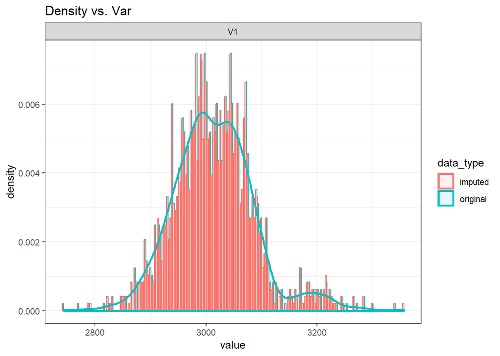

Fig. 2.2: Example distribution before and after imputation

Table 2.2: Summary of data wrangling.

| Metric | Initial | Final |
| --- | --- | --- |
| # of Variables | 593.00 | 417 |
| # of Observations | 1567.00 | 1567 |
| % Missings | 4.51 | 0 |

# 3 Data Exploration

## 3.1 Sensor Data Distributions

An important requirement for developing a multivariate model for this project is how well the individual sensor data distributions can be modeled by a known statistical distribution type. Ideally each variable would follow the well known normal distribution. The figure below shows an example of one variable in the SECOM dataset that is roughly normal based on visual inspect of the probability density (PDF) distribution. Included below that is its corresponding Q-Q plot, or quantile plot, which plots the measured versus theoretical quantile data. For an ideal normal distribution the fit line of a Q-Q plot would be colinear with the data and have very small residuals over the entire +3/-3 z-score range. The farther the fit line deviates from data the less confident we can be that the distribution is normal. A reasonable target is that at least 95% of the data fits the distribution which corresponds to a good fit between z = -1.96 to +1.96. Since the goal of the model in this project is to predict physical wafers failures based on production sensor data, the distribution is also shown comparing passing and failing results Except for differences in the tails, there’s very little distinction between the distributions. Since it’s not known if the differences in the tail data is important or not, the apparent outliers will not be removed from the analysis yet.The second set of plots below show the data for another sensor which also follows a normal distribution, but comparison of yield results shows differences in both the peak probability and tail distribution.

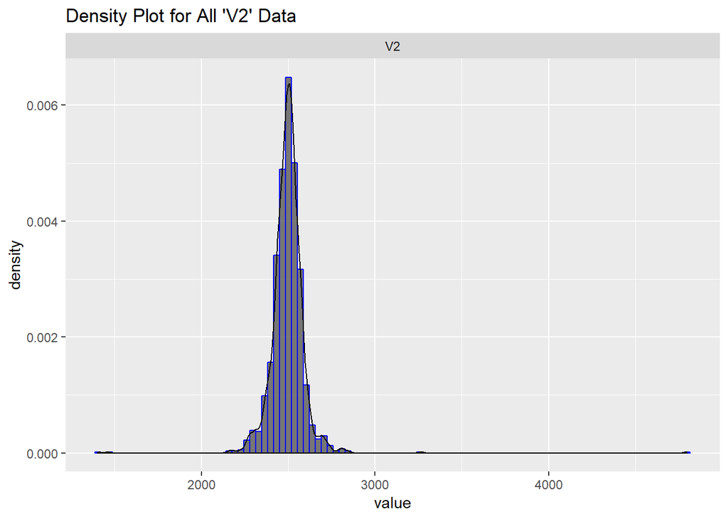

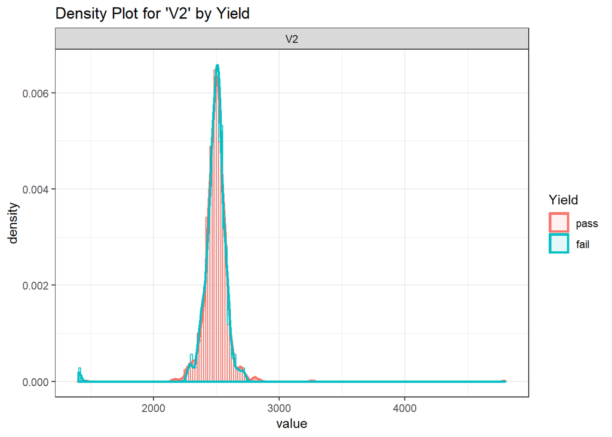

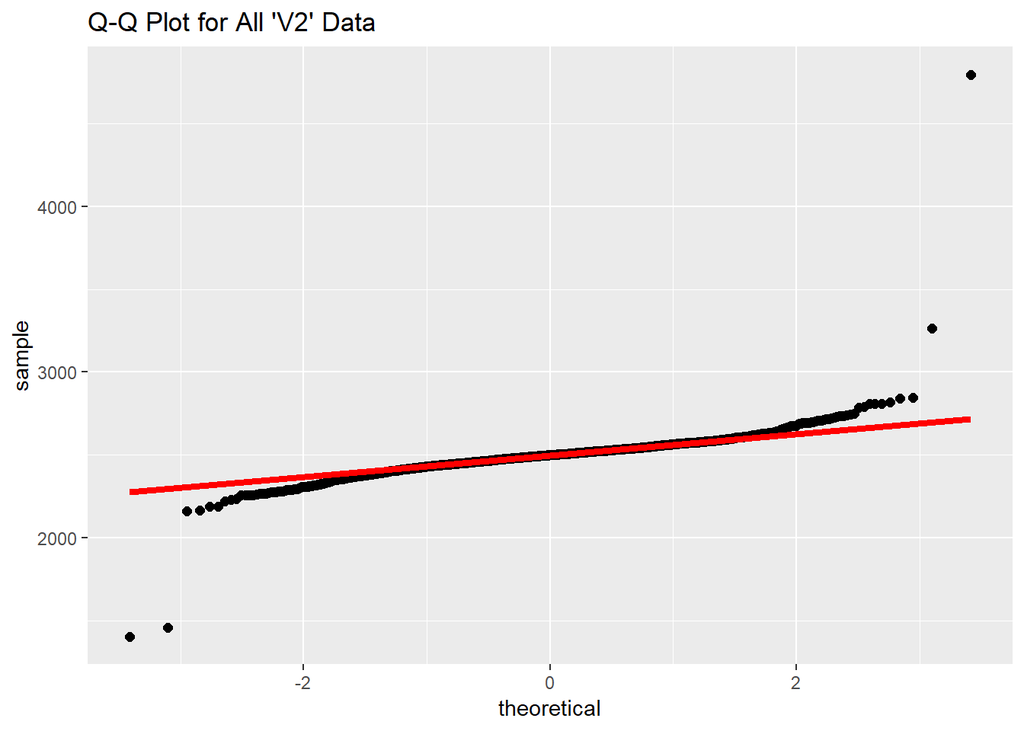

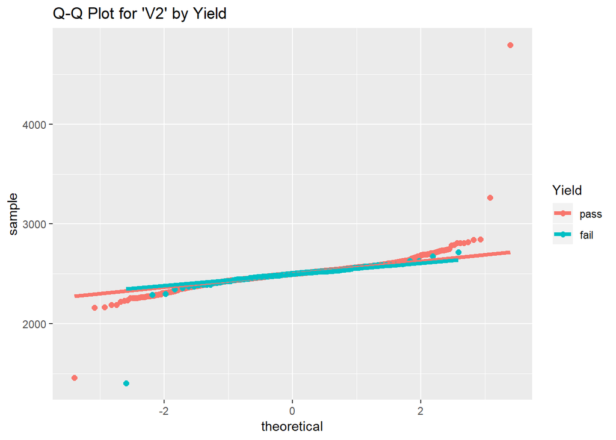

Fig. 3.1: Example of near normal distributions.

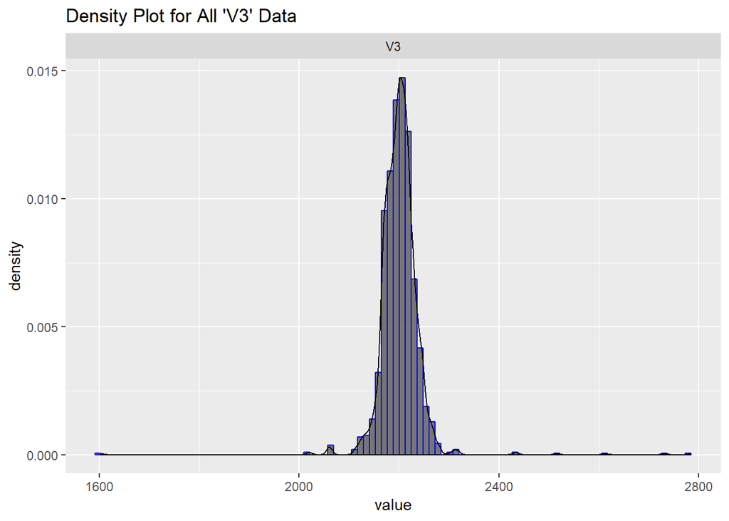

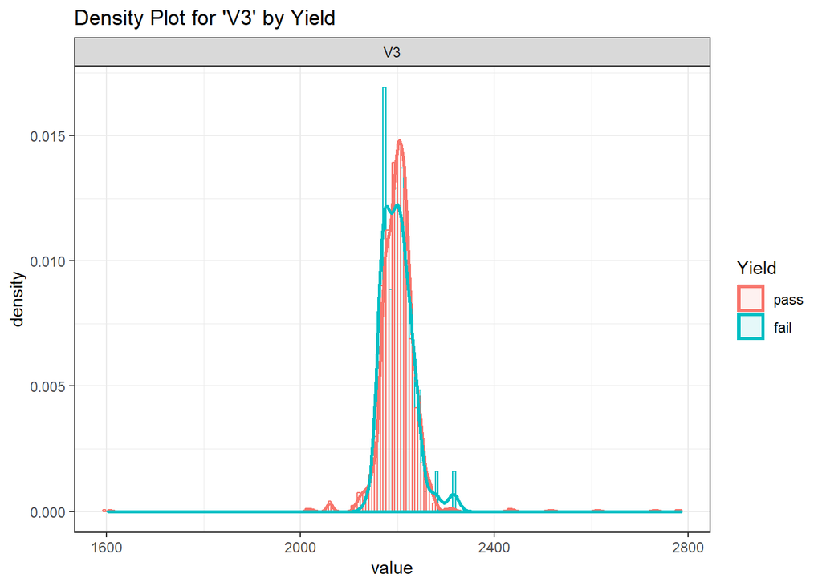

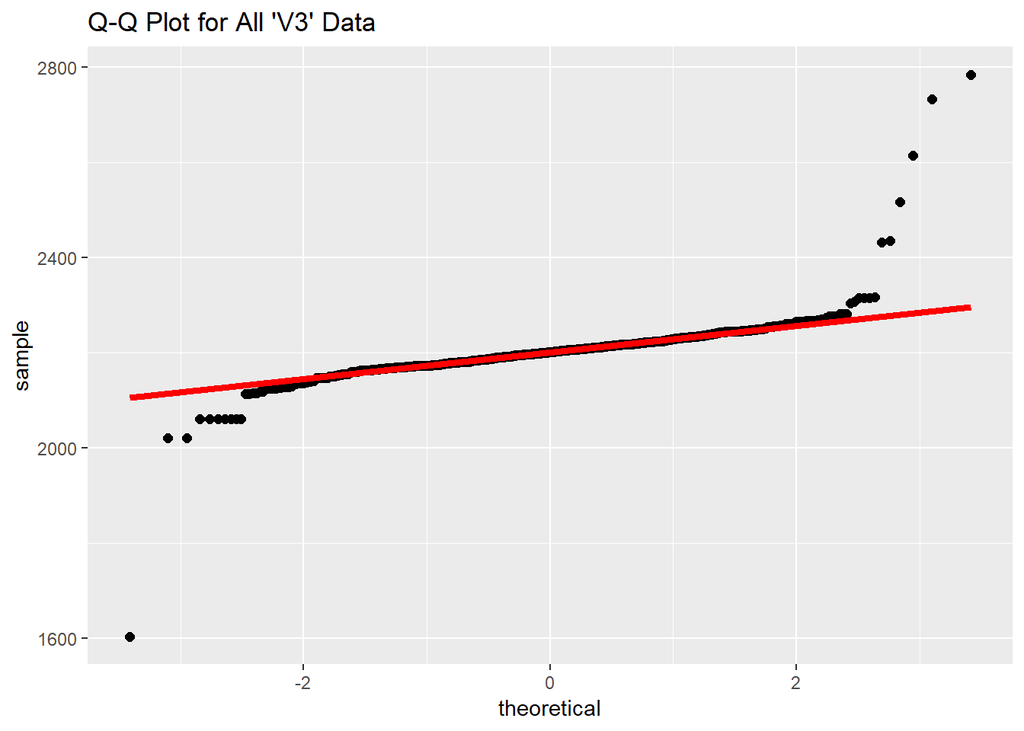

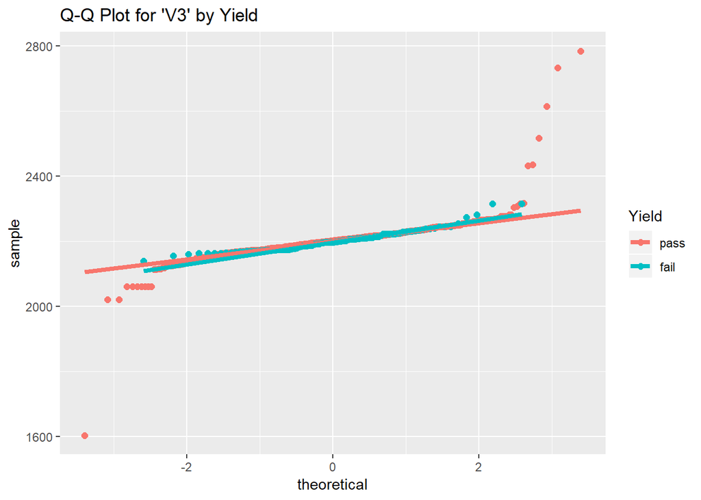

Fig. 3.2: Example of near normal distributions with yield differences.

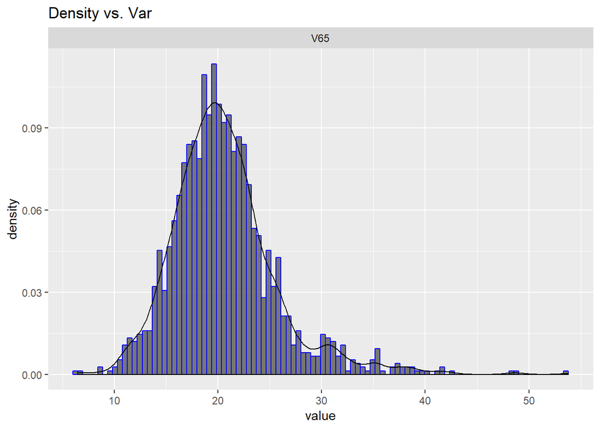

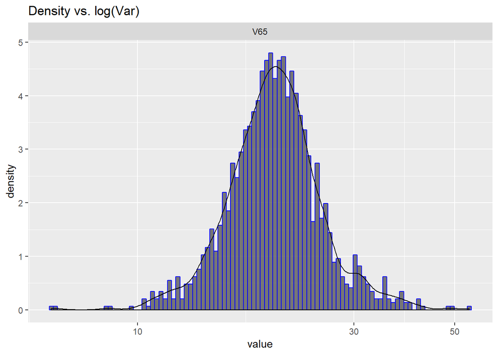

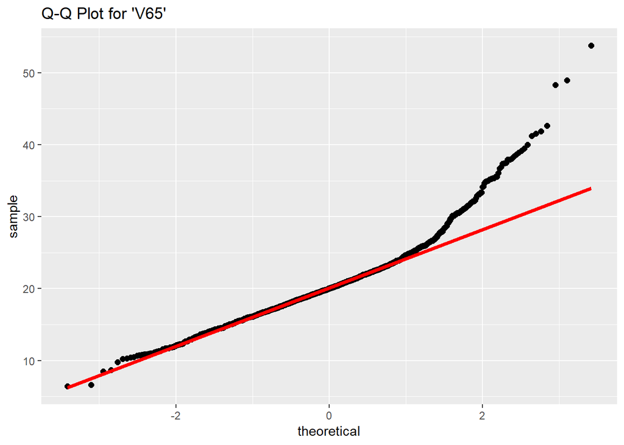

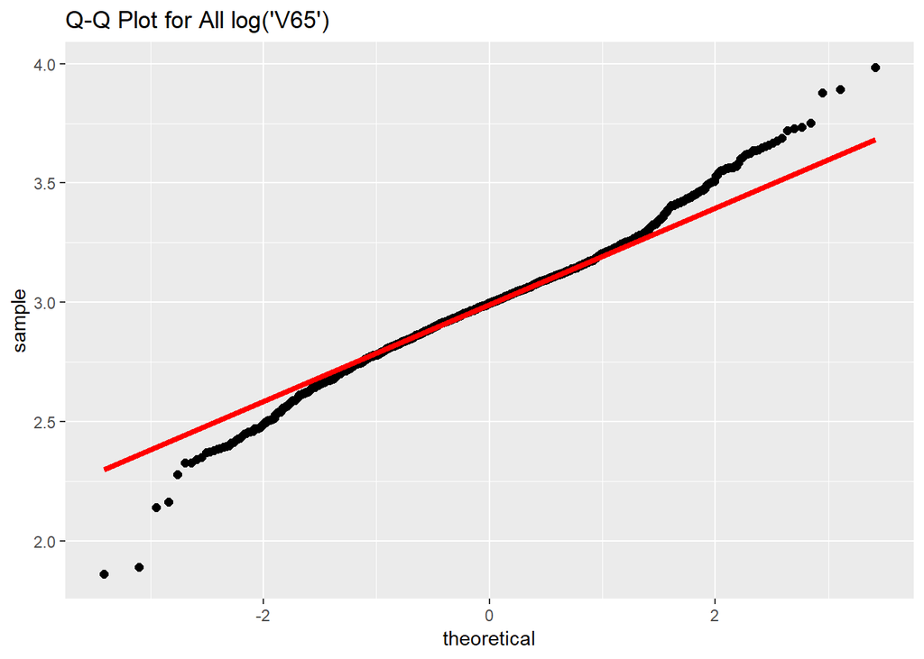

Fig. 3.3: Example skewed distribution.

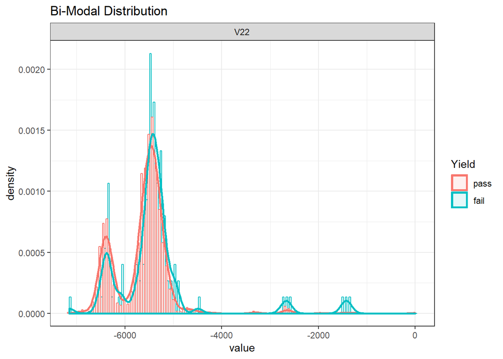

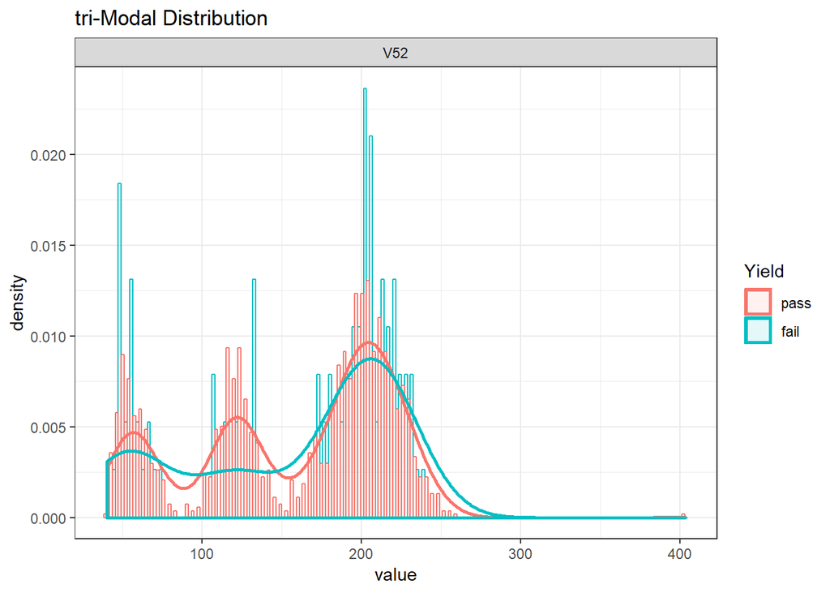

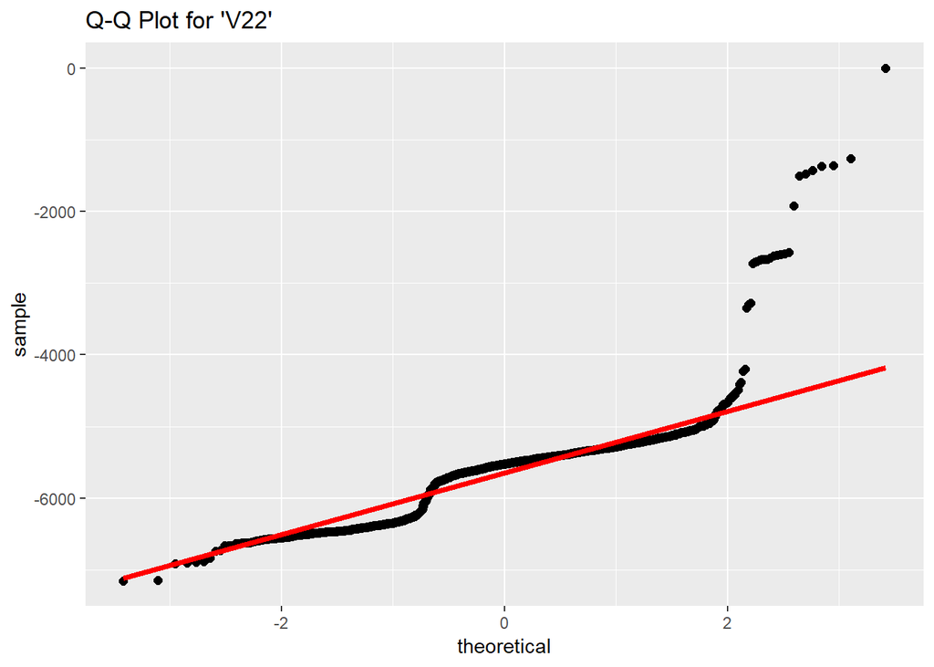

[figure not shown]

Fig. 3.4: Example multi-modal distributions.

## 3.2 Correlation Analysis

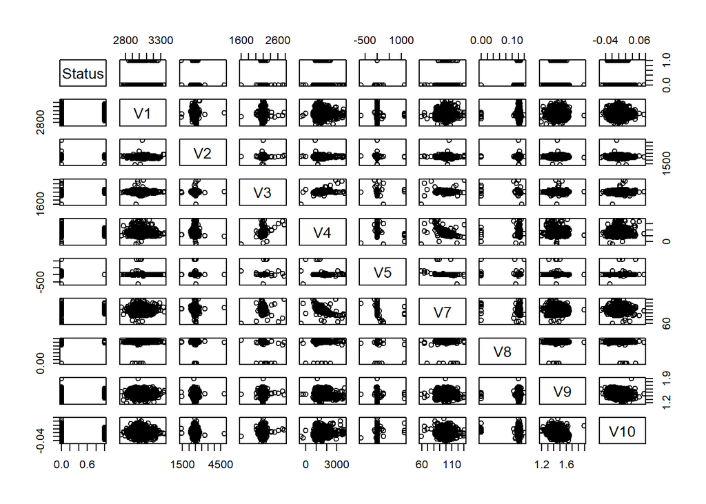

Fig. 3.5: Example scatter plot matrix.

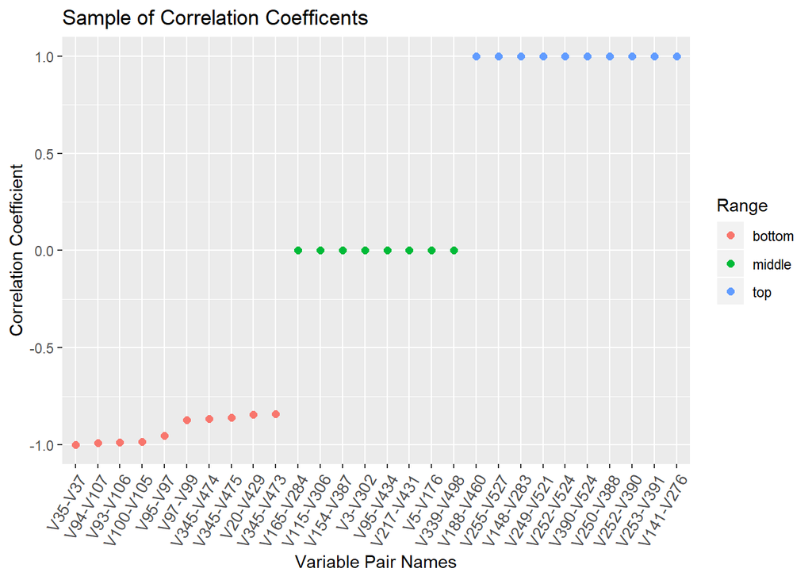

Fig. 3.6: Sample correlation coefficient ranges for the SECOM dataset.

Table 3.1: Data used for Fig. 3.6.

| Range | var1 | var2 | coeff |
| --- | --- | --- | --- |
| bottom | V35 | V37 | -0.9991 |
| bottom | V94 | V107 | -0.9896 |
| bottom | V93 | V106 | -0.9890 |
| bottom | V100 | V105 | -0.9860 |
| bottom | V95 | V97 | -0.9542 |
| bottom | V97 | V99 | -0.8718 |
| bottom | V345 | V474 | -0.8662 |
| bottom | V345 | V475 | -0.8617 |
| bottom | V20 | V429 | -0.8452 |
| bottom | V345 | V473 | -0.8429 |
| middle | V165 | V284 | 0.0000 |
| middle | V115 | V306 | 0.0000 |
| middle | V154 | V387 | 0.0000 |
| middle | V3 | V302 | 0.0000 |
| middle | V95 | V434 | 0.0000 |
| middle | V217 | V431 | 0.0000 |
| middle | V5 | V176 | 0.0000 |
| middle | V339 | V498 | 0.0000 |
| top | V188 | V460 | 0.9992 |
| top | V255 | V527 | 0.9993 |
| top | V148 | V283 | 0.9995 |
| top | V249 | V521 | 0.9997 |
| top | V252 | V524 | 0.9998 |
| top | V390 | V524 | 0.9999 |
| top | V250 | V388 | 0.9999 |
| top | V252 | V390 | 0.9999 |
| top | V253 | V391 | 1.0000 |
| top | V141 | V276 | 1.0000 |

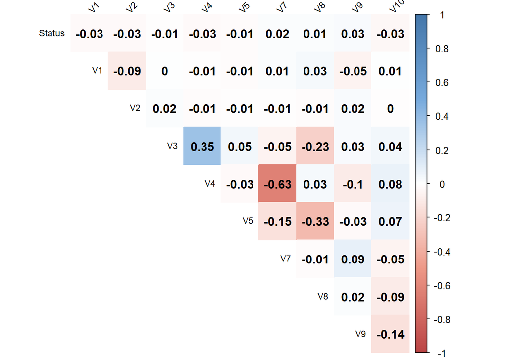

Fig. 3.7: Example correlogram plot.

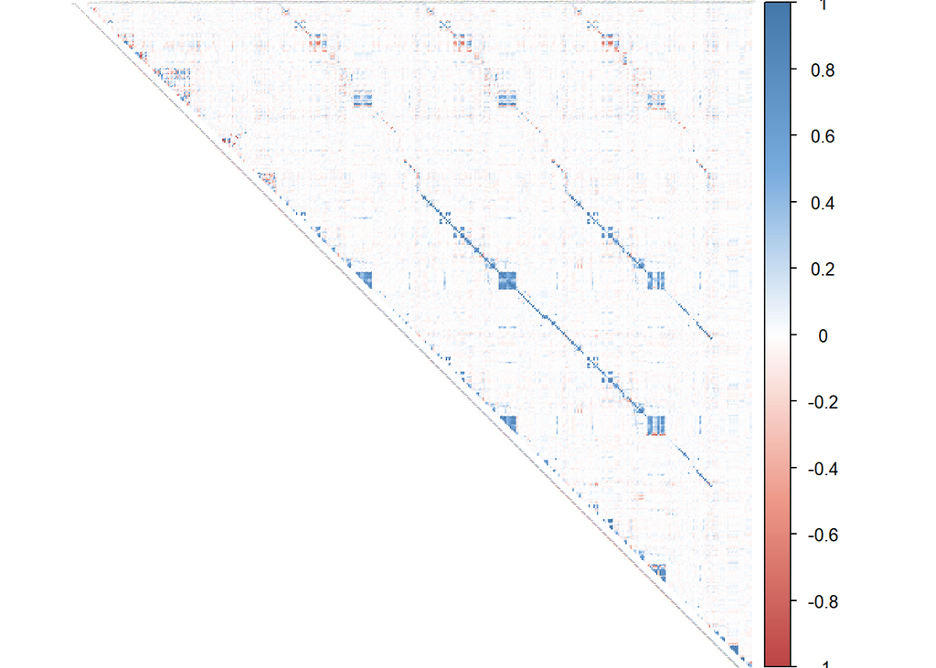

Fig. 3.8: Correlogram plot for the SECOM dataset.

While the number of cross-correlations makes visual analysis cumbersome in general, it is still interesting to review how each variable is correlated to the dependent variable, ‘Status’. Fig. 3.9 plots the SECOM variables ordered by their correlation coefficient with ‘Status’. The notable takeaway is that none of the individual variables is signficantly correlated with the ouput response meaning that the final model should expect to retain a significant number of independent variables.

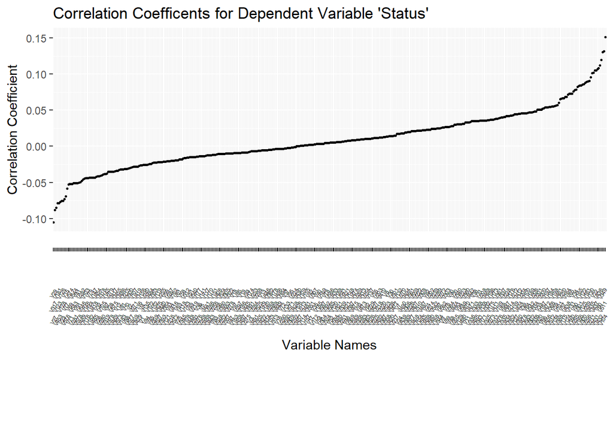

Fig. 3.9: Correlation coefficients for the dependent variable, Status.